# Functional Analysis

## **Topic 1** — Natural Cubic Spline

Computing the natural cubic spline $S$ which interpolates $f$ at the knots 1, 2, and 5.

$$ \begin{array}{l} S_{1,2} =\begin{cases} a_1+b_1 (x-1)+c_1 (x-1)^2+d_1 (x-1)^3,\quad x∈[1,2] \\ a_2+b_2 (x-2)+c_2 (x-2)^2+d_2 (x-2)^3,\quad x∈[2,5] \end{cases} \ \qquad \text{for} \: \ f(x) =\frac{1}{x^{2}} \end{array} $$

Finding the coefficients $a_i$, $b_i$, $c_i$, and $d_i$ of the spline $S$ using Inverse Matrix Method. We get the following equations following the 4 properties of natural cubic spline:

$$ \begin{array}{ l } \text{for} \ x=[1,2,5]\ \text{and} \ y=[1,0.25,\ 0.04]\\ \begin{array}{ l l } \text{we have:} \ & S_{1} (1)=1,\ S_{2} (2)=0.25,\ S_{1} (2)=0.25,\ S_{2} (5)=0.04\\ & S_{1}^{'} (2)=S_{2}^{'} (2)\ \ \ \text{and} \ \ S_{1}^{''} (2)=S_{2}^{''} (2)\\ & S_{1}^{''} (1)=0,\ S_{2}^{''} (5)=0\\ & \text{and}\\ & S^{'} (x)=\begin{cases} b_{1} +2c_{1}( x-1) +3d_{1}( x-1)^{2}, \quad x\in [ 1,2]\\ b_{2} +2c_{2}( x-2) +3d_{2}( x-2)^{2}, \quad x\in [ 2,5] \end{cases}\\ & S^{''} (x)=\begin{cases} 2c_{1} +6d_{1}( x-1) \quad x\in [ 1,2]\\ 2c_{2} +6d_{2}( x-2) \quad x\in [ 2,5] \end{cases} \end{array} \end{array} $$

These break down to the following equations:

$$ \begin{array}{l} a_{1}=1 \\ a_{2}=0.25 \\ a_{1}+b_{1}+c_{1}+d_{1}=0.25 \\ a_{2}+3b_{2}+9c_{2}+27d_{2}=0.04 \\ b_{1}+2c_{1}+3d_{1}-b_{2}=0 \\ c_{1}+3d_{1}-c_{2}=0 \\ c_{1}=0 \\ c_{2}+9d_{2}=0 \end{array} \Rightarrow \begin{array}{ l } A\cdot X=B\\ \begin{bmatrix} \ 1 & 0 & 0 & 0 & 0 & 0 & 0 & 0\\ \ 0 & 0 & 0 & 0 & 1 & 0 & 0 & 0\\ \ 1 & 1 & 1 & 1 & 0 & 0 & 0 & 0\\ \ 0 & 0 & 0 & 0 & 1 & 3 & 9 & 27\\ \ 0 & 1 & 2 & 3 & 0 & -1 & 0 & 0\\ \ 0 & 0 & 1 & 3 & 0 & 0 & -1 & 0\\ \ 0 & 0 & 1 & 0 & 0 & 0 & 0 & 0\\ \ 0 & 0 & 0 & 0 & 0 & 0 & 1 & 9 \end{bmatrix}\begin{bmatrix} a_{1}\\ b_{1}\\ c_{1}\\ d_{1}\\ a_{2}\\ b_{2}\\ c_{2}\\ d_{2} \end{bmatrix} =\begin{bmatrix} \ 1 \\ \ 0.25 \\ \ 0.25 \\ \ 0.04 \\ \ 0 \\ \ 0 \\ \ 0 \\ \ 0 \end{bmatrix} \end{array} $$

Now we calculate $ A^{-1} \cdot B $ to find $ X $ which is the solution of the system of equations.

```python
import numpy as np
import pandas as pd

A = np.array([[1,0,0,0,0,0,0,0],
              [0,0,0,0,1,0,0,0],
              [1,1,1,1,0,0,0,0],
              [0,0,0,0,1,3,9,27],
              [0,1,2,3,0,-1,0,0],
              [0,0,1,3,0,0,-1,0],
              [0,0,1,0,0,0,0,0],
              [0,0,0,0,0,0,1,9]])

B = np.array([1,0.25,0.25,0.04,0,0,0,0])
X = np.linalg.inv(A).dot(B)
coeff = pd.DataFrame(X.reshape(2,4),
                     index=['1','2'],
                     columns=['a','b','c','d'])
print(coeff.round(3))
```

```
      a      b      c      d
1  1.00 -0.835  0.000  0.085
2  0.25 -0.580  0.255 -0.028
```

Now we can use the coefficients $a_i$, $b_i$, $c_i$, and $d_i$ to plot the spline $S$ and the original function $f$.

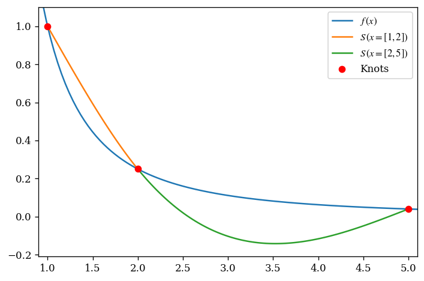

```python
import matplotlib.pyplot as plt
plt.rcParams['figure.dpi'] = 120
plt.rcParams['savefig.dpi'] = 300
plt.rcParams['font.family'] = 'serif'
plt.rcParams['mathtext.fontset'] = 'stix'

def f(x):
    return 1/x**2
def S_1(x):
    return coeff.loc['1','a']+coeff.loc['1','b']*(x-1)+\
           coeff.loc['1','c']*(x-1)**2+coeff.loc['1','d']*(x-1)**3
def S_2(x):
    return coeff.loc['2','a']+coeff.loc['2','b']*(x-2)+\
           coeff.loc['2','c']*(x-2)**2+coeff.loc['2','d']*(x-2)**3

x = np.linspace(0.9,5.1,100)
X_1 = np.linspace(1,2,100)
X_2 = np.linspace(2,5,100)

plt.figure(figsize=(6,4))
plt.plot(x,f(x),label=r'$f\/(x)$')
plt.plot(X_1,S_1(X_1),label=r'$S\/(x=[1,2])$')
plt.plot(X_2,S_2(X_2),label=r'$S\/(x=[2,5])$')
plt.xlim(0.9,5.1)
plt.ylim(-0.21,1.1)
knots = np.array([1,2,5])
plt.plot(knots, f(knots), 'ro', label='Knots')
plt.legend()
plt.tight_layout()
```

## **Topic 2** — Penalized Least Square

Considering the penalized least square problems:

$$ \begin{array}{ l } \hat{f}_{\!1} =\ \underset{f}{\min}\left[\sum _{i=1}^{N}( y_{i} -f( x_{i}))^{2} +\lambda \int _{a}^{b}\left( f^{( m)}( x)\right)^{2} dx\right]\\ \hat{f}_{\!2} =\ \underset{f}{\min}\left[\sum _{i=1}^{N}( y_{i} -f( x_{i}))^{2} +\lambda \int _{a}^{b} \left( f^{( m+k)}( x)\right)^{2} dx\right], \quad \text{with} \ \: k\in \mathbb{Z}^{+} \end{array} $$

#### Part 1: Degree of Polynomial

Finding the degree of polynomial for $\hat{f}_{\!1}$ with the following parameters:

(1) $m=0, \lambda=\infty \quad$ (2) $m=1, \lambda=\infty \quad$ (3) $m=2, \lambda=\infty \quad$ (4) $m=3, \lambda=0$

Let's present all the relevant premises regarding the smoothing factor:

For $\hat{f} =\ \underset{f}{\min}\left[\sum _{i=1}^{N}( y_{i} -f( x_{i}))^{2} +\lambda \int _{a}^{b} (\boldsymbol{F})^{2} dx\right]$, as $\lambda \rightarrow 0$ the penalty loses its effect on the objective function resulting in full interpolation of the data and as $\lambda \rightarrow \infty$ the function is penalized for every point of data, and at $\lambda = \infty$ we'd only have a finite $\hat{f}$ if the integral is zero which only happens if $\boldsymbol{F}=0$.

#### Part 2:

(1) $\;\;$ Will $\hat{f}_{\!1}$ or $\hat{f}_{\!2}$ have the smaller training residual sum of squares as $\lambda \rightarrow \infty$.

By the same reasoning as (1), $\hat{f}_{\!1}$ has a higher smoothing that results in a smaller test residual sum of squares than $\hat{f}_{\!2}$ as $\lambda \rightarrow \infty$.

(3) $\;\;$ Will $\hat{f}_{\!1}$ or $\hat{f}_{\!2}$ have the smaller training and test residual sum of squares as $\lambda \rightarrow 0$.

As penalty disappears $\hat{f}_{\!1}$ and $\hat{f}_{\!2}$ both have the same training and test residual sum of squares are the same.

## **Topic 3** — Smoothing of Soil NIRS Functional Mean Data

Spectra data of 40 soil sample loaded with 1000 predictors per sample. Here we take look at 4 different approaches to smoothing of this signal.  
*Please note that the optimal parameters are reported on the plot of the smoothed data.*

```python
# Loading libraries and setting default parameters
import numpy as np
import matplotlib.pyplot as plt
from sklearn.model_selection import RepeatedKFold
from scipy.interpolate import CubicSpline, splrep, splev, LSQUnivariateSpline
from scipy.signal import convolve

plt.rcParams['figure.dpi'] = 150
```

Since the data we'll be working with is the average of the 40 sample, we've denoted the features as `x` and the functional mean as `y` (similar to what is expected of on an x-y plot).

```python
# Loading The Data
x = np.arange(0,1000)
y = np.mean(np.loadtxt('Question3.csv', delimiter=','), axis=0)
```

```python
# 5-Fold Cross Validation of Signal Data with Natural Cubic Spline Interpolation for number of knots:
kf = RepeatedKFold(n_splits=5, n_repeats=20, random_state=42)
```

```python
# 5-Fold Cross Validation function for Cubic B-Spline Interpolation
def kcv_NCS(kf, x, y, knots):
    MSE = []
    for train_index, test_index in kf.split(x):
        xs = np.linspace(0,train_index.size,knots).astype(int)[1:-1]
        train_index = np.sort(train_index)
        tck = LSQUnivariateSpline(train_index, y[train_index], k=3, t=xs)
        y_pred = tck(test_index)
        MSE.append(np.mean((y_pred - y[test_index]) ** 2))
    return np.mean(MSE)
```

```python
# 5-Fold Cross Validation function for Cubic B-Spline Interpolation
def kcv_CBS(kf, x, y, knots):
    MSE = []
    for train_index, test_index in kf.split(x):
        xs = np.linspace(0,train_index.size,knots).astype(int)[1:-1]
        train_index = np.sort(train_index)
        # xs = train_index[xs]
        tck = splrep(train_index, y[train_index], k=3, s=0, t=xs)
        y_pred = splev(test_index, tck)
        MSE.append(np.mean((y_pred - y[test_index]) ** 2))
    return np.mean(MSE)
```

```python
MSE_NCS = []
params_NCS = np.arange(5,51)
for knot in params_NCS:
    MSE_NCS.append(kcv_NCS(kf, x, y, knot))
```

```python
MSE_CBS = []
params_CBS = np.arange(5,51)
for knot in params_CBS:
    MSE_CBS.append(kcv_CBS(kf, x, y, knot))
```

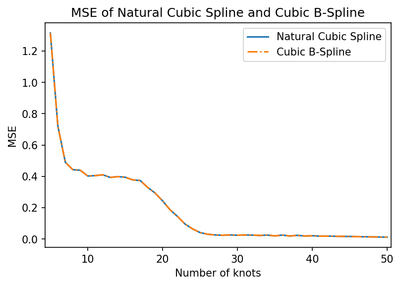

```python
# Plot of MSE of Natural Cubic Spline and Cubic B-Spline for number of knots
plt.plot(params_NCS, MSE_NCS, label='Natural Cubic Spline')
plt.plot(params_CBS, MSE_CBS, '-.', label='Cubic B-Spline')
plt.xlim(4.3,50.5)
plt.xlabel('Number of knots')
plt.ylabel('MSE')
plt.title('MSE of Natural Cubic Spline and Cubic B-Spline')
plt.legend()
plt.show()
```

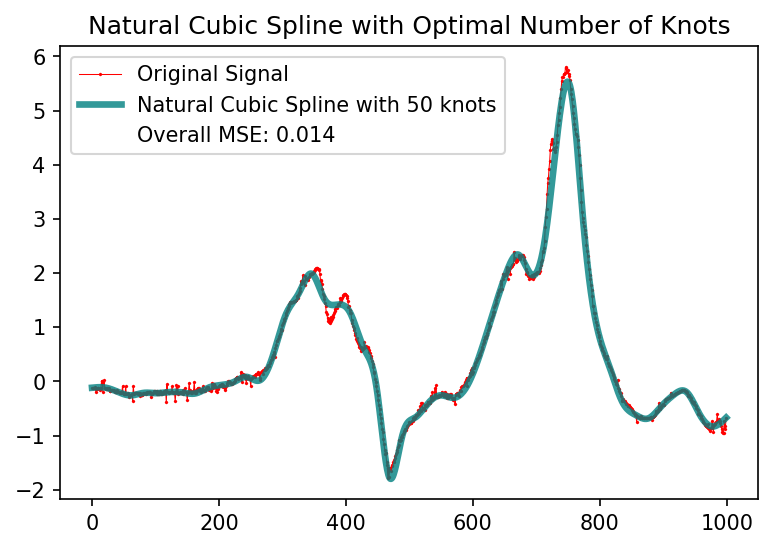

```python
# Natural Cubic Spline Interpolation with optimal number of knots
knots = params_NCS[np.argmin(MSE_NCS)]
xs = np.linspace(0,999,knots).astype(int)
cs = CubicSpline(xs, y[xs], bc_type='natural')
y_NCS = cs(x)

# Plot of the interpolated signal data and the original signal data
plt.plot(x, y, marker='x',label='Original Signal', markersize=1, color='red',
         linewidth=0.5)
plt.plot(x, y_NCS, label='Natural Cubic Spline with ' + str(knots) + ' knots',
         color='teal', linewidth=3.2, alpha=0.8)
plt.plot([],[], ' ', label=r'Overall MSE: '+str(np.round(np.mean((y_NCS - y)**2),3)))
plt.title('Natural Cubic Spline with Optimal Number of Knots')
plt.legend()
plt.show()
```

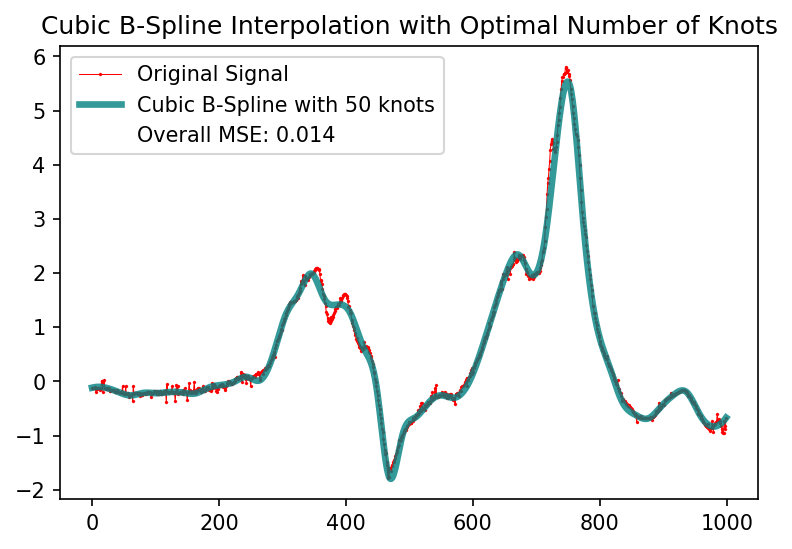

```python
# Cubic B-Spline Interpolation with optimal number of knots
knots = params_CBS[np.argmin(MSE_CBS)]
xs = np.linspace(0,999,knots).astype(int)
tck = splrep(xs, y[xs], k=3, s=0)
y_CBS = splev(x, tck)

# Plot of the interpolated signal data and the original signal data
plt.plot(x, y, marker='x',label='Original Signal', markersize=1, color='red',
         linewidth=0.5)
plt.plot(x, y_CBS, label='Cubic B-Spline with ' + str(knots) + ' knots',
         color='teal', linewidth=3.2, alpha=0.8)
plt.plot([],[], ' ', label=r'Overall MSE: '+str(np.round(np.mean((y_CBS - y)**2),3)))
plt.title('Cubic B-Spline Interpolation with Optimal Number of Knots')
plt.legend()
plt.show()
```

```python
# 5-Fold Cross Validation function for Smoothing Spline Interpolation for optimal lambda
def kcv_SS(kf, x, y, lam):
    MSE = []
    for train_index, test_index in kf.split(x):
        xs = np.sort(train_index)
        ys = y[xs]
        tck = splrep(xs, ys, k=3, s=lam)
        y_pred = splev(test_index, tck)
        MSE.append(np.mean((y_pred - y[test_index]) ** 2))
    return np.mean(MSE)
```

```python
MSE_SSS = []  # Averaging over 5 runs for a smoother swoosh!
for i in range(5):
    MSE_SS = []
    params_SS = np.linspace(0.9,3,20)
    for lam in params_SS:
        MSE_SS.append(kcv_SS(kf, x, y, lam))
    MSE_SSS.append(MSE_SS)
```

```python
MSE_SSS = np.mean(np.array(MSE_SSS),axis=0)
```

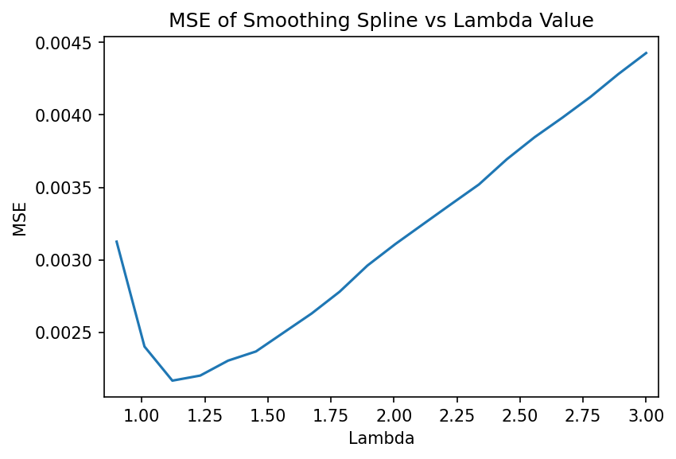

```python
# Plot of the MSE of Smoothing Spline Interpolation vs Lambda
plt.plot(params_SS, MSE_SSS)
plt.xlabel('Lambda')
plt.ylabel('MSE')
plt.title('MSE of Smoothing Spline vs Lambda Value')
plt.xlim(0.85,3.05)
plt.show()
```

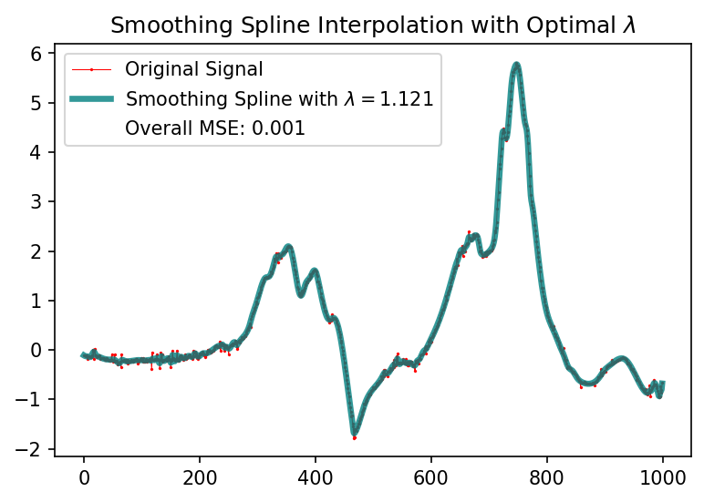

```python
# Smoothing Spline Interpolation with optimal lambda
lam = params_SS[np.argmin(MSE_SS)]
xs = np.sort(x)
ys = y[xs]
tck = splrep(xs, ys, k=3, s=lam)
y_SS = splev(x, tck)

# Plot of the interpolated signal data and the original signal data
plt.plot(x, y, marker='x',label='Original Signal', markersize=1, color='red',
         linewidth=0.5)
plt.plot(x, y_SS, label=r'Smoothing Spline with $\lambda=$'+ str(np.round(lam,3)),
         color='teal', linewidth=3.2, alpha=0.8)
plt.plot([],[], ' ', label=r'Overall MSE: '+str(np.round(np.mean((y_SS - y)**2),3)))
plt.title(r'Smoothing Spline Interpolation with Optimal $\lambda$')
plt.legend()
plt.show()
```

```python
# Gauassian Kernel Smoothing
def gaussian_kernel(x, y, sigma):
    return np.exp(-(x - y) ** 2 / (2 * sigma ** 2)) / (np.sqrt(2 * np.pi) * sigma)
def smooth(x, y, h):
    return convolve(y, gaussian_kernel(x, x, h), mode='same') / convolve(
        np.ones_like(y), gaussian_kernel(x, x, h), mode='same')
def kern_interp(x, y, xi, h):
    return np.array([np.sum(y * gaussian_kernel(x, xi_i, h)) for xi_i in xi])

# Custom 5-Fold Cross Validation function for Gaussian Kernel Smoothing with optimal bandwidth
def kcv_GS(kf, x, y, bw):
    MSE = []
    for train_index, test_index in kf.split(x):
        xs = np.sort(train_index)
        ys = y[xs]
        y_pred = kern_interp(xs, ys, test_index, bw)
        MSE.append(np.mean((y_pred - y[test_index]) ** 2))
    return np.mean(MSE)
```

```python
MSE_GS = []
params_GS = np.linspace(2,30,30)
for bw in params_GS:
    MSE_GS.append(kcv_GS(kf, x, y, bw))
```

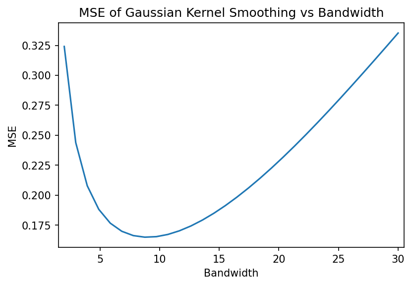

```python
# Plotting the MSE of Gaussian Kernel Smoothing vs Bandwidth
plt.plot(params_GS, MSE_GS)
plt.xlabel('Bandwidth')
plt.ylabel('MSE')
plt.title('MSE of Gaussian Kernel Smoothing vs Bandwidth')
plt.xlim(1.5,30.5)
plt.show()
```

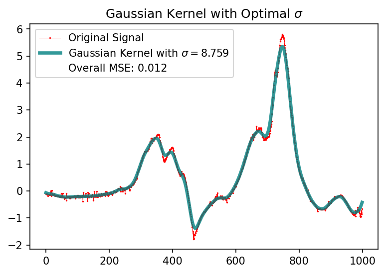

```python
# Gaussian Kernel Smoothing with optimal bandwidth
bw = params_GS[np.argmin(MSE_GS)]
y_GS = kern_interp(x, y, x, bw)

# Plot of the interpolated signal data and the original signal data
plt.plot(x, y, marker='x',label='Original Signal', markersize=1, color='red',
         linewidth=0.5)
plt.plot(x, y_GS, label=r'Gaussian Kernel with $\sigma=$'+ str(np.round(bw,3)),
         color='teal', linewidth=3.2, alpha=0.8)
plt.plot([],[], ' ', label=r'Overall MSE: '+str(np.round(np.mean((y_GS - y)**2),3)))
plt.title(r'Gaussian Kernel with Optimal $\sigma$')
plt.legend()
plt.show()
```

## **Topic 4** — Dimensionality Reduction for Olive Oil Functional Data

### Part 1: Cubic Spline Feature Extraction

Spectra data for 60 different olive oil samples are loaded into a dataframe.

```python
import pandas as pd
from utils_4 import SVM_bspline, SVM_fPCA, plt_cm
```

```python
data = pd.read_csv('Question4.csv', header=None)
x, y = data.iloc[:, :-1], data.iloc[:, -1]
```

Function `SVM_bspline` in `utils_4.py` was coded to for following instructions: Data is split to test and train sets 30/30 without shuffle, the function then fits the train data to the following pipeline of transformers:

- Mean subtraction and variance Scaling (1)
- Scaling to [0,1] (1)
- Cubic Spline with 70 knots Coefficients
- Mean subtraction and variance Scaling (2)
- Scaling to [0,1] (2)
- SVM with RBF Kernel

Test data is then transformed by the fitted pipeline to produce the test prediction. Test prediction and actuals are then used for the classification reports and the confusion matrix. *Both the structure of the pipelines and SVM parameters were optimized using with different CV approaches some of which can be found in the `utils_4.py` file.*

```
Cubic B-Spline with 70 knots Feature Extraction
SVM Classification Report:
              precision    recall  f1-score   support

      Greece       1.00      1.00      1.00         5
       Italy       0.82      1.00      0.90         9
    Portugal       1.00      0.50      0.67         4
       Spain       0.92      0.92      0.92        12

    accuracy                           0.90        30
   macro avg       0.93      0.85      0.87        30
weighted avg       0.91      0.90      0.89        30
```

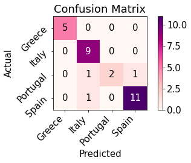

```python
print("Cubic B-Spline with 70 knots Feature Extraction")
_, bspline_cm = SVM_bspline(x,y)
_ = plt_cm(bspline_cm)
```

### Part 2: Functional PCA Feature Extraction

Function `SVM_fPCA` in `utils_.py` was coded to for following instructions: Data is split to test and train sets 30/30 without shuffle, the function then fits the train data to the following pipeline of transformers:

- Mean subtraction and variance Scaling (1)
- FDataGrid Converter
- fPCA Components' Coefficients
- Mean subtraction and variance Scaling (2)
- Scaling to [0,1]
- SVM with RBF Kernel

From here, the steps follow the same procedure as above.

```
fPCA with 2 harmonics Feature Extraction
SVM Classification Report:
              precision    recall  f1-score   support

      Greece       1.00      1.00      1.00         5
       Italy       0.75      1.00      0.86         9
    Portugal       1.00      0.25      0.40         4
       Spain       0.92      0.92      0.92        12

    accuracy                           0.87        30
   macro avg       0.92      0.79      0.79        30
weighted avg       0.89      0.87      0.84        30
```

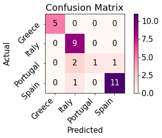

```python
print("fPCA with 2 harmonics Feature Extraction")
_, fPCA_cm = SVM_fPCA(x,y,2)
_ = plt_cm(fPCA_cm)
```

```
fPCA with 5 harmonics Feature Extraction
SVM Classification Report:
              precision    recall  f1-score   support

      Greece       1.00      1.00      1.00         5
       Italy       0.82      1.00      0.90         9
    Portugal       1.00      0.25      0.40         4
       Spain       0.85      0.92      0.88        12

    accuracy                           0.87        30
   macro avg       0.92      0.79      0.79        30
weighted avg       0.88      0.87      0.84        30
```

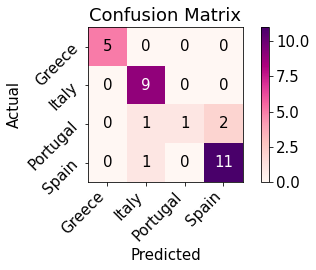

```python
print("fPCA with 5 harmonics Feature Extraction")
_, fPCA_cm = SVM_fPCA(x,y,5,16)
_ = plt_cm(fPCA_cm)
```

```
fPCA with 8 harmonics Feature Extraction
SVM Classification Report:
              precision    recall  f1-score   support

      Greece       1.00      0.80      0.89         5
       Italy       0.90      1.00      0.95         9
    Portugal       1.00      0.75      0.86         4
       Spain       0.85      0.92      0.88        12

    accuracy                           0.90        30
   macro avg       0.94      0.87      0.89        30
weighted avg       0.91      0.90      0.90        30
```

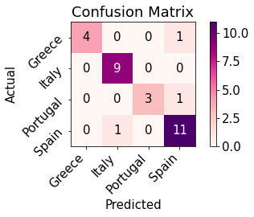

```python
print("fPCA with 8 harmonics Feature Extraction")
_, fPCA_cm = SVM_fPCA(x,y,8)
_ = plt_cm(fPCA_cm)
```

```
fPCA with 10 harmonics Feature Extraction
SVM Classification Report:
              precision    recall  f1-score   support

      Greece       1.00      1.00      1.00         5
       Italy       0.90      1.00      0.95         9
    Portugal       1.00      0.75      0.86         4
       Spain       0.92      0.92      0.92        12

    accuracy                           0.93        30
   macro avg       0.95      0.92      0.93        30
weighted avg       0.94      0.93      0.93        30
```

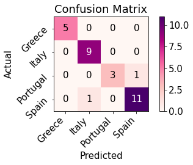

```python
print("fPCA with 10 harmonics Feature Extraction")
_, fPCA_cm = SVM_fPCA(x,y,10,15,0.3)
_ = plt_cm(fPCA_cm)
```

Below is the entirety of the code from the `utils_4.py` file:

```python
### Helper Functions for Q4
# Importing libraries
import matplotlib.pyplot as plt
import numpy as np
import pandas as pd
import skfda
from scipy.interpolate import splrep
from skfda.preprocessing.dim_reduction.feature_extraction import FPCA
from sklearn.base import BaseEstimator, TransformerMixin
from sklearn.metrics import (classification_report,
                             confusion_matrix)
from sklearn.model_selection import RepeatedStratifiedKFold
from sklearn.model_selection import train_test_split, GridSearchCV
from sklearn.pipeline import Pipeline
from sklearn.preprocessing import StandardScaler, MinMaxScaler
from sklearn.svm import SVC

# %% Part 1
class_names = ['Greece', 'Italy', 'Portugal', 'Spain']

# Produces the 70-knot B-spline coefficients per data point
def bsplinec(row):
    x = np.array(row)
    knots = np.linspace(0, row.size, 68)[1:-1]
    tck = splrep(np.arange(row.size), x, k=3, t=knots)
    return tck[1][:-4]


# Custom Transformer for `bsplinec`
class BSplineC(BaseEstimator, TransformerMixin):
    def __init__(self):
        pass

    def fit(self, X, y=None):
        return self

    def transform(self, X):
        return np.apply_along_axis(bsplinec, 1, X)


# SVM Classification with Cubic B-spline Feature Extraction
def SVM_bspline(X, y, clf=SVC(kernel='rbf', C=16, gamma=0.2)):
    x_train, x_test, y_train, y_test =
    train_test_split(X, y, test_size=30, shuffle=False)

    scaler_pre = StandardScaler()
    scaler_post = StandardScaler()
    min_max_pre = MinMaxScaler()
    min_max_post = MinMaxScaler()

    pipe = Pipeline(steps=[('pre_scale', scaler_pre),
                           ('pre_minmax', min_max_pre),
                           ('bspline', BSplineC()),
                           ('post_scale', scaler_post),
                           ('post_minmax', min_max_post),
                           ('clf', clf)])

    pipe.fit(x_train, y_train)
    y_pred = pipe.predict(x_test)
    print("SVM Classification Report:\n" +
          classification_report(y_test, y_pred,
                                target_names=class_names))
    return y_pred, confusion_matrix(y_test, y_pred)


# %% Part 2
# Custom Transformer for to convert a dataframe to a skfda.FDataGrid
class DfToFdat(BaseEstimator, TransformerMixin):
    def __init__(self):
        pass

    def fit(self, X, y=None):
        return self

    def transform(self, X):
        X_ = pd.DataFrame(X)
        return df_to_fdat(X_)

# Function to convert a dataframe to a FPCA object
def df_to_fdat(df):
    grid_pnts = df.columns.tolist()
    data_matrix = df.values.tolist()
    return skfda.FDataGrid(data_matrix, grid_pnts)

# SVM Classification with fPCA Feature Extraction
def SVM_fPCA(x, y, n_components, c=4, gamma=0.62):
    x_train, x_test, y_train, y_test =
    train_test_split(x, y, test_size=30, shuffle=False)

    scaler_pre = StandardScaler()
    scaler_post = StandardScaler()
    min_max_post = MinMaxScaler()

    pipe = Pipeline(steps=[
        ('scaler_pre', scaler_pre),
        ('df_to_fdat', DfToFdat()),
        ('fPCA', FPCA(n_components=n_components)),
        ('scaler_post', scaler_post),
        ('min_max_post', min_max_post),
        ('SVC', SVC(kernel='rbf', C=c, gamma=gamma))])

    pipe.fit(x_train, y_train)
    y_test_pred = pipe.predict(x_test)
    print("SVM Classification Report:\n" +
          classification_report(y_test, y_test_pred,
                                target_names=class_names))
    return y_test_pred, confusion_matrix(y_test, y_test_pred)


# %% CV Grid Search
# Cross-Validation for SVM Classification with fPCA Feature Extraction
def SVM_fPCA_CV(x, y, n_components, k=5, repeats=5, param_grid=None):
    rskf = RepeatedStratifiedKFold(n_splits=k,
                                   n_repeats=repeats,
                                   random_state=42)
    pipe = Pipeline(steps=[
        ('df_to_fdat', DfToFdat()),
        ('fPCA', FPCA(n_components=n_components)),
        ('SVC', SVC(kernel='rbf', C=16, gamma=0.2))])

    scaler_pre = StandardScaler()
    scaler_post = StandardScaler()
    min_max_post = MinMaxScaler()

    pipe = Pipeline(steps=[
        ('scaler_pre', scaler_pre),
        ('df_to_fdat', DfToFdat()),
        ('fPCA', FPCA(n_components=n_components)),
        ('scaler_post', scaler_post),
        ('min_max_post', min_max_post),
        ('SVC', SVC(kernel='rbf'))])

    if param_grid is None:
        param_grid = {
            'SVC__C': [1, 2, 4, 8, 16, 32],
            'SVC__gamma': [0.38, 0.44, 0.5, 0.56, 0.62, 0.68, 0.74]
        }

    search = GridSearchCV(pipe, param_grid, cv=rskf,
                          n_jobs=-1, verbose=1)
    search.fit(x, y)

    print("Best parameter (CV score=%0.3f):" % search.best_score_)
    print(search.best_params_)
    return search

# %% Confusion Matrix Plotting Function
def plt_cm(cmat):
    plt.rc('font', size=15)

    fig, ax = plt.subplots()
    im = ax.imshow(cmat, cmap='RdPu')
    ax.figure.colorbar(im, ax=ax)
    ax.set(xticks=np.arange(cmat.shape[1]),
           yticks=np.arange(cmat.shape[0]))
    ax.set_xticklabels(class_names)
    ax.set_yticklabels(class_names, rotation=45)
    plt.setp(ax.get_xticklabels(), rotation=45, ha="right")
    ax.set_xlabel('Predicted')
    ax.set_ylabel('Actual')
    for i in range(cmat.shape[0]):
        for j in range(cmat.shape[1]):
            _ = ax.text(j, i, cmat[i, j], ha="center", va="center",
                        color="w" if cmat[i, j] > cmat.max() / 2.1 else "k")
    plt.title('Confusion Matrix')
    fig.tight_layout()
    plt.show()
    return ax
```